# EZBHDDM - Simple hypothesis testing example

Adriana F. Chávez De la Peña and Joachim Vandekerckhove

2024-12-03

# Introduction

Data from [Vandekerckhove, Panis and Wagemans (2007)](https://link.springer.com/article/10.3758/BF03193960)

```r
# Load necessary libraries/packages
library(R2jags)
seed <- 15
```

# Loading and prepare the data

```r
# Read the data file
data_raw <- read.csv("./data/vpw08.csv")

# Change column names
colnames(data_raw) <- c("sub", "change_quality", "change_type", "noChange", "response", "rt")

# Clean up data
# Remove RTs larger than 3 seconds
tmp <- data_raw[which(data_raw$rt<=3),]
# Identify each condition
change <- 1-tmp$noChange
cond <- rep(0,nrow(tmp))
cond[which(tmp$change_quality==0&tmp$change_type==0)] <- 1
cond[which(tmp$change_quality==1&tmp$change_type==0)] <- 2
cond[which(tmp$change_quality==0&tmp$change_type==1)] <- 3
cond[which(tmp$change_quality==1&tmp$change_type==1)] <- 4
cond[which(change==0)] <- 5

# Prepare final data set to use for our analysis
data <- data.frame("sub" = tmp$sub, "cond" = cond, "change" = change,
                   "change_quality" = tmp$change_quality, "change_type" = tmp$change_type,
                   "response" = tmp$response, "rt" = tmp$rt)
```

```r
# No. of observations
nrow(data)
```

```
## [1] 5722
```

# Get summary statistics

**Note:** Since the three-parameters considered by the EZDDM formulation don’t predict any difference in shape between the correct and incorrect RT distributions, we use all trials to compute the mean and variance of the RT.

### Write custom function `ez_summaries`

```r
######################################################################
# A custom function to compute EZ summary statistics
######################################################################

ez_summaries <- function(data){
  # Identify condition and subject ID
  cond <- unique(data$cond)
  sub <- unique(data$sub)
  # Prepare EZ statistics
  output<- c()
  for(i in sort(sub)){
    # For each subject...
    for(k in sort(cond)){
      # On each condition...
      # Isolate the data
      subset <- data[which(data$sub==i&data$cond==k),]
      # And prepare summary statistics
      output <- rbind(output, c("sub" = unique(subset$sub), "cond" = unique(subset$cond),
                                "change" = unique(subset$change),
                                "change_quality" = unique(subset$change_quality),
                                "change_type" = unique(subset$change_type),
                                "nTrials" = nrow(subset), "score" = sum(subset$response),
                                "meanRT"  = mean(subset$rt), "varRT"= var(subset$rt)))
    }
  }
  # Return data frame with summary statistics per condition and subject
  return(as.data.frame(output))
}
```

### Compute summary statistics from data

```r
ezdata <- ez_summaries(data)
ezdata$acc_rate <- ezdata$score/ezdata$nTrials
```

# The model

### EZHBDM

The first component of the model is what we called ‘the proxy’ model: We use the sampling distributions for the three summary statistics computed from the data, (i.e., the number of correct responses $\dot{T}$ and the mean $\dot{M}$ and variance $\dot{V}$ of the response times), which are built from the forward-system of equations in the EZDDM that characterize the proportion of correct responses `PC`, and the mean and precision of the RTs `MRT`, `PRT`.

### Meta-regression structure

We model the variability in the drift rate $\drift$ parameter across conditions $k$ by fitting a multiple linear regression

so that the drift rate predicted for every condition $\drift^{pred}_k$ depends on the configuration of the three dummy variables and their interaction with five different regression coefficients.

```r
# Is there a change?
# Yes (1) / No (0)
X <- ezdata$change

# Change quality
# Quantitative (1) / Qualitative (0)
Y <- ezdata$change_quality

# Change type
# Concavity (1) / Convexity (0)
Z <- ezdata$change_type
```

### Write the model in JAGS

```r
model <- write("
    model {
              ####### Priors
              drift_mu ~ dnorm(0,1)   # Baseline
              drift_lambda ~ dgamma(2,1)
              drift_sigma = pow(drift_lambda, -0.5)
              for(i in 1:4){
                  gamma[i] ~ dnorm(0,1)
              }

              for(j in 1:5){
                  drift_pred[j] = drift_mu + X[j]*(gamma[1]*Y[j]+gamma[2]*Z[j]+gamma[3]*Y[j]*Z[j]) + (1-X[j])*gamma[4]
              }

              ####### Sampling model
              for (k in 1:length(nTrials)) {
                  # Person-by-condition parameters for DM parameters
                  bound[k] ~ dgamma(2,1)
                  nondt[k] ~ dexp(1)
                  drift[k] ~ dnorm(drift_pred[cond[k]],drift_lambda)

                  # Forward equations from EZ Diffusion
                  ey[k]  = exp(-bound[k] * drift[k])
                  Pc[k]  = 1 / (1 + ey[k])
                  PRT[k] = 2 * pow(drift[k], 3) / bound[k] * pow(ey[k] + 1, 2) / (2 * -bound[k] *
                           drift[k] * ey[k] - ey[k] * ey[k] + 1)
                  MDT[k] = (bound[k] / (2 * drift[k])) * (1 - ey[k]) / (1 + ey[k])
                  MRT[k] = MDT[k] + nondt[k]

                  # Sampling distributions for summary statistics
                  correct[k] ~ dbin(Pc[k], nTrials[k])
                  varRT[k]   ~ dnorm(1/PRT[k], 0.5*(nTrials[k]-1) * PRT[k] * PRT[k])
                  meanRT[k]  ~ dnorm(MRT[k], PRT[k] * nTrials[k])
                }
    }", "./multlinearreg_model.bug")
```

# JAGS

### Specify JAGS setup

```r
# General setup
n.chains  <- 4;      n.iter    <- 2500
n.burnin  <- 250;    n.thin    <- 1

# Pass data to JAGS
data_toJAGS <- list("nTrials"  =  ezdata$nTrials,
                    "meanRT"   =  ezdata$meanRT,
                    "varRT"    =  ezdata$varRT,
                    "correct"  =  ezdata$score,
                    "cond"     =  ezdata$cond,
                    "X" = X, "Y" = Y, "Z" = Z)

# Specify parameters to keep track of
parameters <- c('gamma', 'drift_mu', 'drift_lambda', 'drift_sigma', 'drift_pred',
                'drift','bound', 'nondt', "Pc", "PRT", "MRT")
```

```r
set.seed(seed)

# Prepare initial values
myinits <- rep(list(list()), n.chains)
for(i in 1:n.chains){
    myinits[[i]] <- list(drift = rnorm(nrow(ezdata),0,1))
}
```

### Run JAGS

```r
set.seed(seed)

start <- Sys.time()
samples <- jags(data=data_toJAGS,
                parameters.to.save=parameters,
                model="./multlinearreg_model.bug",
                n.chains=n.chains,  n.iter=1000,
                n.burnin=100,  n.thin=n.thin,
                DIC=T, inits=myinits)
```

```
## module glm loaded
```

```r
end <- Sys.time()

save(samples,file="./results/samples.RData")
save(data_toJAGS, file="./results/data_toJAGS.RData")
```

[output not shown]

### Extract posterior samples

```r
##### Drift rate parameters
# Recovered drift rates
drift <- samples$BUGSoutput$sims.list$drift
# Regression coefficients
mu <- samples$BUGSoutput$sims.list$drift_mu
gamma <- samples$BUGSoutput$sims.list$gamma
# Fitted values / Predicted drift rates
drift_pred <- samples$BUGSoutput$sims.list$drift_pred

##### Summary statistics computed from the recovered drift and boundary
Pc   <- samples$BUGSoutput$sims.list$Pc
PRT  <- samples$BUGSoutput$sims.list$PRT
MRT  <- samples$BUGSoutput$sims.list$MRT
```

### Obtain posterior predicted summary statistics

```r
set.seed(seed)

# Number of trials per condition
nTrials <- ezdata$nTrials
# Number of posterior samples
n <- nrow(Pc)
# Number of conditions
J <- ncol(Pc)
# Empty matrices to store posterior predictions
pp_accRate <- matrix(NA, nrow=n, ncol=J)
pp_meanRT  <- matrix(NA, nrow=n, ncol=J)
pp_varRT   <- matrix(NA, nrow=n, ncol=J)
# Obtain posterior predictions using sampling distributions
#        and the summary statistics derived from the recovered
#        drift and boundary parameters
for(i in 1:J){
  correct  <-  rbinom(n,nTrials[i],Pc[,i])
  pp_accRate[,i] <- correct/nTrials[i]
  pp_varRT[,i]   <- rnorm(n,1/PRT[,i], sqrt(2/((nTrials[i]-1) * PRT[,i] * PRT[,i])))
  pp_meanRT[,i]  <- rnorm(n,MRT[,i],sqrt(1/(PRT[,i]*nTrials[i])))
}
```

# Results

## Drift predicted per condition

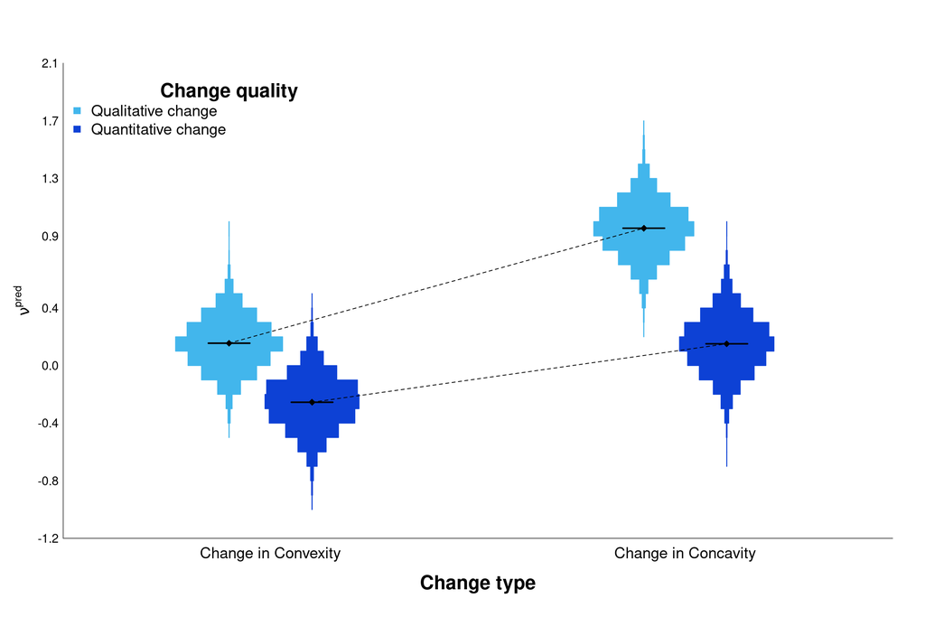

## Posterior regression coefficients

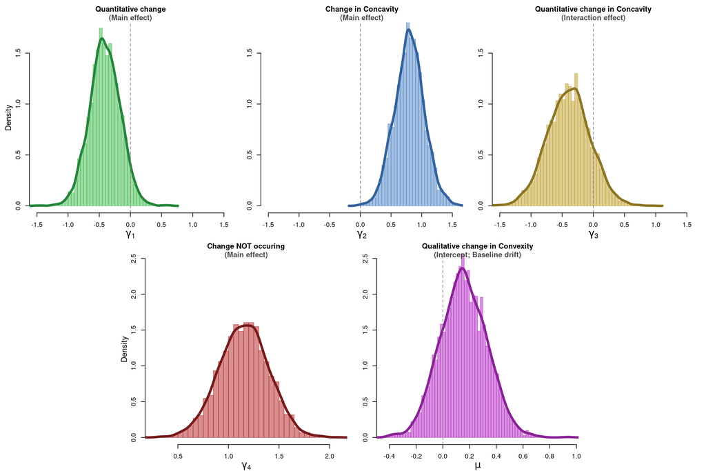

# Posterior predictive checks

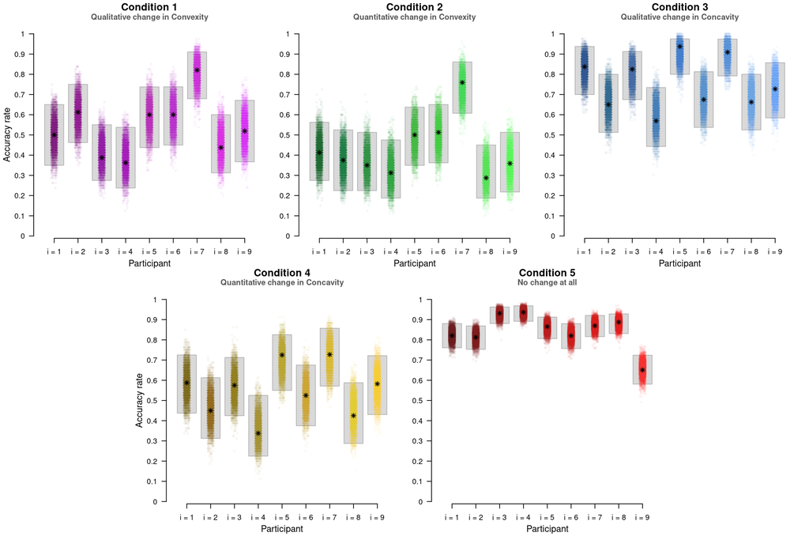

```r
#####################
#   Accuracy rate   #
#####################
iter <- nrow(pp_accRate)
jitter.x <- runif(iter,-0.12,0.12)

# Initialize plotting space
layout(mat = matrix(c(1,1,2,2,3,3,
                      0,4,4,5,5,0), nrow = 2, byrow = TRUE))
par(pty="m", mai=c(0.45,0.5,0.25,0), oma= c(0,0,1,1.5))

plot_ppAcc <- function(pp_accRate, ezdata){
     for(k in 1:5){
          plot(4.5, 10, col="white", ylim=c(0,1), xlim=c(0.5,9.5),ann=F,axes=F)
          axis(1,seq(1,9,length.out=9),paste("i =",1:9), line=-0.65)
          axis(2,seq(0,1,0.1), seq(0,1,0.1),las=1)
          mtext("Participant",1,line=1.7,cex=0.8)
          for(i in 1:9){
            this.Y <- pp_accRate[,seq(k,ncol(pp_accRate),5)[i]]
            CI <- quantile(this.Y, probs = c(0.025,0.975))
            polygon(x=c(i-0.4,i+0.4,i+0.4,i-0.4),y=c(CI[1],CI[1],CI[2],CI[2]), col="gray85", border="gray70")
            points(i+jitter.x,this.Y, col=myCol(r[,k],g[,k],b[,k],i,0.05), pch=16, cex=0.8)
            points(i, ezdata$acc_rate[which(ezdata$cond==k)][i], pch=8)
          }
          mtext(paste("Condition", k), f=2, line=1.5, cex=0.9)
          if(k==1){mtext("Qualitative change in Convexity", f=2, line=.5, cex=0.7, col="gray35")}
          if(k==2){mtext("Quantitative change in Convexity", f=2, line=.5, cex=0.7, col="gray35")}
          if(k==3){mtext("Qualitative change in Concavity", f=2, line=.5, cex=0.7, col="gray35")}
          if(k==4){mtext("Quantitative change in Concavity", f=2, line=.5, cex=0.7, col="gray35")}
          if(k==5){mtext("No change at all", f=2, line=.5, cex=0.7, col="gray35")}
          if(k==1|k==4){ mtext("Accuracy rate", 2, line=2.5, cex=0.8) }
     }
}

plot_ppAcc(pp_accRate, ezdata)
```

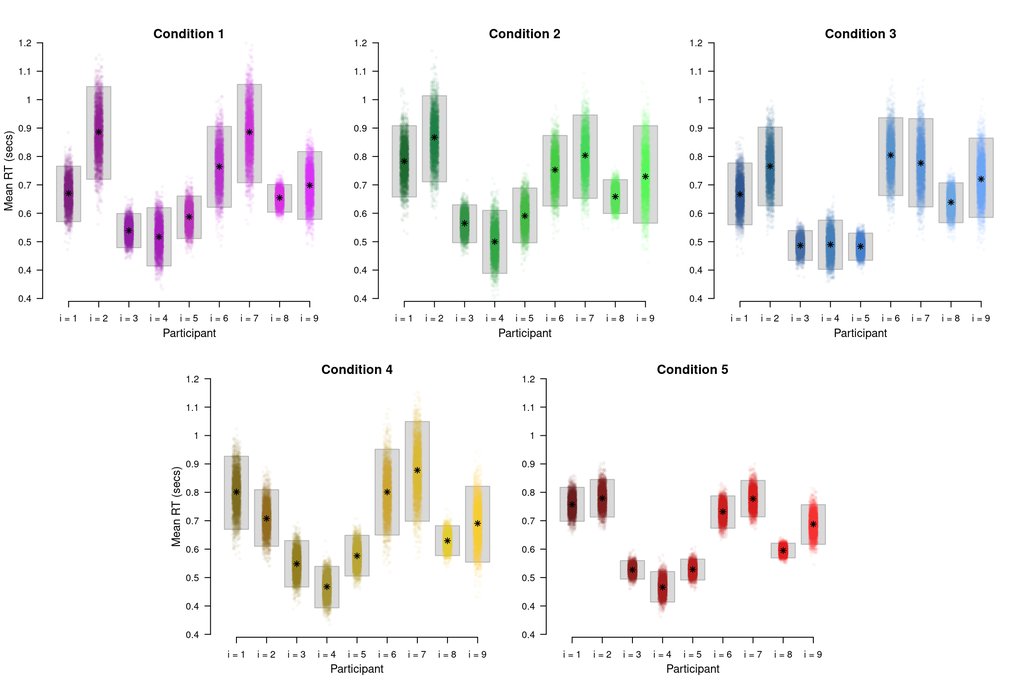

```r
################
#   Mean RT    #
################
iter <- nrow(pp_varRT)
jitter.x <- runif(iter,-0.12,0.12)

# Initialize plotting space
layout(mat = matrix(c(1,1,2,2,3,3,
                      0,4,4,5,5,0), nrow = 2, byrow = TRUE))
par(pty="m", mai=c(0.45,0.5,0.25,0), oma= c(0,0,1,1.5))

plot_ppMeanRT <- function(pp_meanRT, ezdata){
     minY <- min(pp_meanRT)
     maxY <- max(pp_meanRT)
     for(k in 1:5){
          plot(4.5, 10, col="white", ylim=c(minY,maxY), xlim=c(0.5,9.5),ann=F,axes=F)
          axis(1,seq(1,9,length.out=9),paste("i =",1:9), line=-0.65)
          axis(2,seq(minY,maxY,length.out=10), round(seq(minY,maxY,length.out=10),1),las=1)
          mtext("Participant",1,line=1.7,cex=0.8)
          for(i in 1:9){
            this.Y <- pp_meanRT[,seq(k,ncol(pp_meanRT),5)[i]]
            CI <- quantile(this.Y, probs = c(0.025,0.975))
            polygon(x=c(i-0.4,i+0.4,i+0.4,i-0.4),y=c(CI[1],CI[1],CI[2],CI[2]), col="gray85", border="gray70")
            points(i+jitter.x,this.Y, col=myCol(r[,k],g[,k],b[,k],i,0.05), pch=16, cex=0.8)
            points(i, ezdata$meanRT[which(ezdata$cond==k)][i], pch=8)
          }
          mtext(paste("Condition", k), f=2, line=-0.7, cex=0.9)
          if(k==1|k==4){ mtext("Mean RT (secs)", 2, line=2.5, cex=0.8) }
     }
}

plot_ppMeanRT(pp_meanRT, ezdata)
```

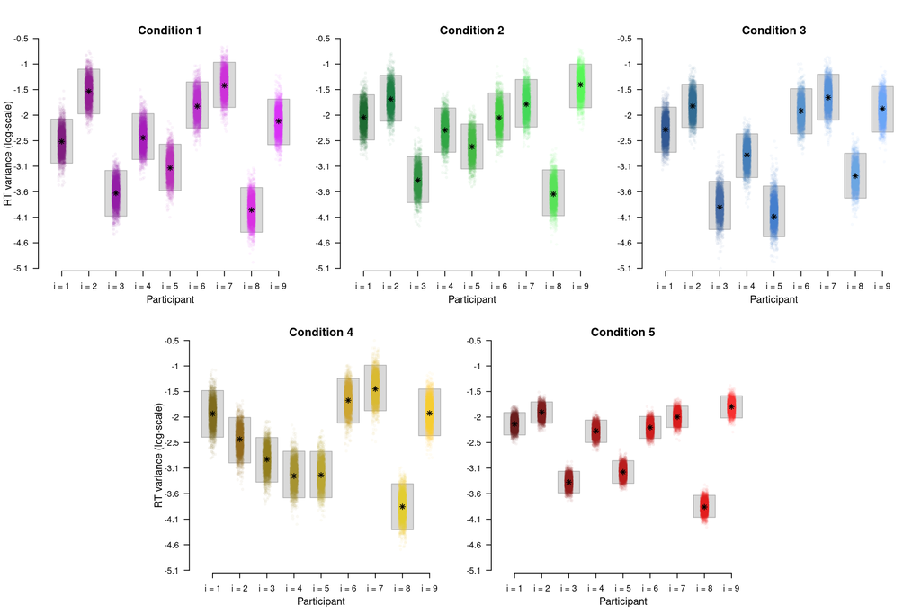

```r
################
#   Variance RT    #
################
iter <- nrow(pp_meanRT)
jitter.x <- runif(iter,-0.12,0.12)

# Initialize plotting space
layout(mat = matrix(c(1,1,2,2,3,3,
                      0,4,4,5,5,0), nrow = 2, byrow = TRUE))
par(pty="m", mai=c(0.45,0.5,0.25,0), oma= c(0,0,1,1.5))

plot_ppvarRT <- function(pp_varRT, ezdata){
     ppl_varRT <- log(pp_varRT)
     minY <- min(ppl_varRT)
     maxY <- max(ppl_varRT)
     for(k in 1:5){
          plot(4.5, 10, col="white", ylim=c(minY,maxY), xlim=c(0.5,9.5),ann=F,axes=F)
          axis(1,seq(1,9,length.out=9),paste("i =",1:9), line=-0.65)
          axis(2,seq(minY,maxY,length.out=10), round(seq(minY,maxY,length.out=10),1),las=1)
          mtext("Participant",1,line=1.7,cex=0.8)
          for(i in 1:9){
            this.Y <- ppl_varRT[,seq(k,ncol(ppl_varRT),5)[i]]
            CI <- quantile(this.Y, probs = c(0.025,0.975))
            polygon(x=c(i-0.4,i+0.4,i+0.4,i-0.4),y=c(CI[1],CI[1],CI[2],CI[2]), col="gray85", border="gray70")
            points(i+jitter.x,this.Y, col=myCol(r[,k],g[,k],b[,k],i,0.05), pch=16, cex=0.8)
            points(i, log(ezdata$varRT[which(ezdata$cond==k)][i]), pch=8)
          }
          mtext(paste("Condition", k), f=2, line=-0.7, cex=0.9)
          if(k==1|k==4){ mtext("RT variance (log-scale)", 2, line=2.5, cex=0.8) }
     }
}

plot_ppvarRT(pp_varRT, ezdata)
```

```r
png(file = "../../figures/shapeEx_postpred_Full.png", width = 8, height = 11, units="in",res=300)
layout(mat = matrix(1:15, ncol=3, byrow=FALSE))
layout.show(n = 15)
par(pty="m", mai=c(0.1,0.5,0,0), oma= c(2.4,3.4,2.5,0.4), bg=NA)


for(k in 1:5){
  plot(4.5, 10, col="white", ylim=c(0,1), xlim=c(0.5,9.5),ann=F,axes=F)
  axis(1,seq(1,9,length.out=9),rep("",9), line=-0.65)
  axis(2,seq(0,1,0.1), seq(0,1,0.1),las=1, cex.axis=0.7)
  for(i in 1:9){
    this.Y <- pp_accRate[,seq(k,ncol(pp_accRate),5)[i]]
    CI <- quantile(this.Y, probs = c(0.025,0.975))
    polygon(x=c(i-0.4,i+0.4,i+0.4,i-0.4),y=c(CI[1],CI[1],CI[2],CI[2]), col="gray85", border="gray70")
    points(i+jitter.x,this.Y, col=myCol(r[,1],g[,1],b[,1],i,0.05), pch=16, cex=0.8)
    points(i, ezdata$acc_rate[which(ezdata$cond==k)][i], pch=8)
  }
  mtext(paste("Condition", k), 2, f=2, line=6, cex=1)
  mtext("Accuracy rate", 2, line=2.1, cex=0.6)
  if(k==1){
    mtext("Accuracy rate", f=2, line=.5, cex=1)
    mtext("Qualitative change", 2, f=2, line=5, cex=0.75, col="gray50")
    mtext("in Convexity", 2, f=2, line=4.1, cex=0.75, col="gray50")}
  if(k==2){
    mtext("Quantitative change", 2, f=2, line=5, cex=0.75, col="gray50")
    mtext("in Convexity", 2, f=2, line=4.1, cex=0.75, col="gray50")}
  if(k==3){
    mtext("Qualitative change", 2, f=2, line=5, cex=0.75, col="gray50")
    mtext("in Concavity", 2, f=2, line=4.1, cex=0.75, col="gray50")}
  if(k==4){
    mtext("Quantitative change", 2, f=2, line=5, cex=0.75, col="gray50")
    mtext("in Concavity", 2, f=2, line=4.1, cex=0.75, col="gray50")}
  if(k==5){mtext("No change at all", 2, f=2, line=5, cex=0.75, col="gray50")
    mtext("Participant",1,line=1.7,cex=0.8)
    axis(1,seq(1,9,length.out=9),paste("p", 1:9, sep=""), line=-1, tick=FALSE, cex.axis=0.8)}
}


minY <- min(pp_meanRT)
maxY <- max(pp_meanRT)
for(k in 1:5){
  plot(4.5, 10, col="white", ylim=c(minY,maxY), xlim=c(0.5,9.5),ann=F,axes=F)
  axis(1,seq(1,9,length.out=9),rep("",9), line=-0.65)
  axis(2,seq(minY,maxY,length.out=10), round(seq(minY,maxY,length.out=10),1),las=1, cex.axis=0.7)
  for(i in 1:9){
    this.Y <- pp_meanRT[,seq(k,ncol(pp_meanRT),5)[i]]
    CI <- quantile(this.Y, probs = c(0.025,0.975))
    polygon(x=c(i-0.4,i+0.4,i+0.4,i-0.4),y=c(CI[1],CI[1],CI[2],CI[2]), col="gray85", border="gray70")
    points(i+jitter.x,this.Y, col=myCol(r[,2],g[,2],b[,2],i,0.05), pch=16, cex=0.8)
    points(i, ezdata$meanRT[which(ezdata$cond==k)][i], pch=8)
  }
  mtext("Mean RT (secs)", 2, line=2.1, cex=0.6)
  if(k==1){mtext("Mean RT (secs)", f=2, line=.5, cex=1)}
  if(k==5){mtext("Participant",1,line=1.7,cex=0.8)
           axis(1,seq(1,9,length.out=9),paste("p", 1:9, sep=""), line=-1, tick=FALSE, cex.axis=0.8)}
}


ppl_varRT <- log(pp_varRT)
minY <- min(ppl_varRT)
maxY <- max(ppl_varRT)
for(k in 1:5){
  plot(4.5, 10, col="white", ylim=c(minY,maxY), xlim=c(0.5,9.5),ann=F,axes=F)
  axis(1,seq(1,9,length.out=9),rep("",9), line=-0.65)
  axis(2,seq(minY,maxY,length.out=10), round(seq(minY,maxY,length.out=10),1),las=1, cex.axis=0.7)
  for(i in 1:9){
    this.Y <- ppl_varRT[,seq(k,ncol(ppl_varRT),5)[i]]
    CI <- quantile(this.Y, probs = c(0.025,0.975))
    polygon(x=c(i-0.4,i+0.4,i+0.4,i-0.4),y=c(CI[1],CI[1],CI[2],CI[2]), col="gray85", border="gray70")
    points(i+jitter.x,this.Y, col=myCol(r[,3],g[,3],b[,3],i,0.05), pch=16, cex=0.8)
    points(i, log(ezdata$varRT[which(ezdata$cond==k)][i]), pch=8)
  }
  mtext("RT variance (log-scale)", 2, line=2.1, cex=0.6)
  if(k==1){
    mtext("RT variance (logs)", f=2, line=.5, cex=1)}
  if(k==5){mtext("Participant",1,line=1.7,cex=0.8)
    axis(1,seq(1,9,length.out=9),paste("p", 1:9, sep=""), line=-1, tick=FALSE, cex.axis=0.8)}

}
dev.off()
```